# Ejercicio_Penguins

Alejandro Sanchez

1/17/2022

## Cargo los datos y las librerias utilizadas

```r
#install.packages("palmerpenguins")
library(palmerpenguins)
library(dplyr)
library(plyr)
```

```r
library(ggplot2)
library(patchwork)

data(package = 'palmerpenguins')
```

## Ej 1) Número de individuos totales (1.1.), masculinos y femeninos por especie (1.2.).

```r
species <- group_by(penguins, species)
dplyr::count(species)
```

```
## # A tibble: 3 x 2
## # Groups:   species [3]
##   species       n
##   <fct>     <int>
## 1 Adelie      152
## 2 Chinstrap    68
## 3 Gentoo      124
```

## 1.1.

1 Adelie 152 2 Chinstrap 68 3 Gentoo 124

```r
sex <- group_by(penguins, sex)
dplyr::count(species, sex)
```

```
## # A tibble: 8 x 3
## # Groups:   species [3]
##   species   sex        n
##   <fct>     <fct>  <int>
## 1 Adelie    female    73
## 2 Adelie    male      73
## 3 Adelie    <NA>       6
## 4 Chinstrap female    34
## 5 Chinstrap male      34
## 6 Gentoo    female    58
## 7 Gentoo    male      61
## 8 Gentoo    <NA>       5
```

## 1.2.

**1** Adelie female 73 **2** Adelie male 73 **3** Adelie NA 6

**4** Chinstrap female 34 **5** Chinstrap male 34

**6** Gentoo female 58 **7** Gentoo male 61 **8** Gentoo NA 5

## 1.3)La media, desviación estándar, valor mínimo y máximo de la longitud #y profundidad del pico, la longitud de la aleta y el tamaño.

### Longitud Pico

```r
media1 <- mean(penguins$bill_length_mm, na.rm = TRUE)
desvest1 <- sd(penguins$bill_length_mm, na.rm = TRUE)
minim1 <- min(penguins$bill_length_mm, na.rm = TRUE)
maxim1 <- max(penguins$bill_length_mm, na.rm = TRUE)

est_long_pico <- c(media1, desvest1, minim1, maxim1)
est_long_pico
```

```
## [1] 43.921930  5.459584 32.100000 59.600000
```

### Profundidad Pico

```r
media2 <- mean(penguins$bill_depth_mm, na.rm = TRUE)
desvest2 <- sd(penguins$bill_depth_mm, na.rm = TRUE)
minim2 <- min(penguins$bill_depth_mm, na.rm = TRUE)
maxim2 <- max(penguins$bill_depth_mm, na.rm = TRUE)

est_prof_pico <- c(media2, desvest2, minim2, maxim2)
est_prof_pico
```

```
## [1] 17.151170  1.974793 13.100000 21.500000
```

### Longitud Aleta

```r
media3 <- mean(penguins$flipper_length_mm, na.rm = TRUE)
desvest3 <- sd(penguins$flipper_length_mm, na.rm = TRUE)
minim3 <- min(penguins$flipper_length_mm, na.rm = TRUE)
maxim3 <- max(penguins$flipper_length_mm, na.rm = TRUE)

est_long_aleta <- c(media3, desvest3, minim3, maxim3)
est_long_aleta
```

```
## [1] 200.91520  14.06171 172.00000 231.00000
```

### Tamaño (masa)

```r
media4 <- mean(penguins$body_mass_g, na.rm = TRUE)
desvest4 <- sd(penguins$body_mass_g, na.rm = TRUE)
minim4 <- min(penguins$body_mass_g, na.rm = TRUE)
maxim4 <- max(penguins$body_mass_g, na.rm = TRUE)

est_body_weight <- c(media4, desvest4, minim4, maxim4)
est_body_weight
```

```
## [1] 4201.7544  801.9545 2700.0000 6300.0000
```

## 2)Un gráfico de barras que represente el número de individuos muestreados de cada especie en cada isla, ## representando las especies en diferentes colores (chinstrap – morado, gentoo – azul, adelie – naranja).

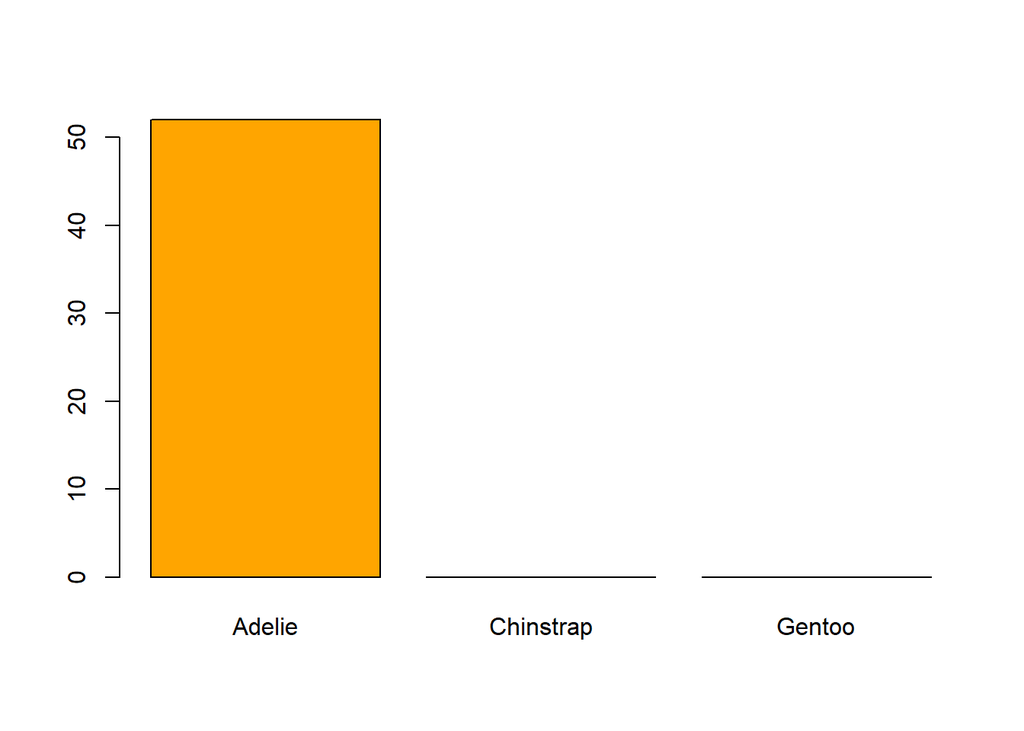

```r
nombreIslas <- levels(penguins$island)

islaTorgen<- penguins[penguins$island == "Torgersen",]
islaDream <- penguins[penguins$island == "Dream",]
islaBiscoe <- penguins[penguins$island == "Biscoe",]

countTorgen <- table(islaTorgen$species)
barplot(countTorgen, col = c("orange", "purple", "blue"))
```

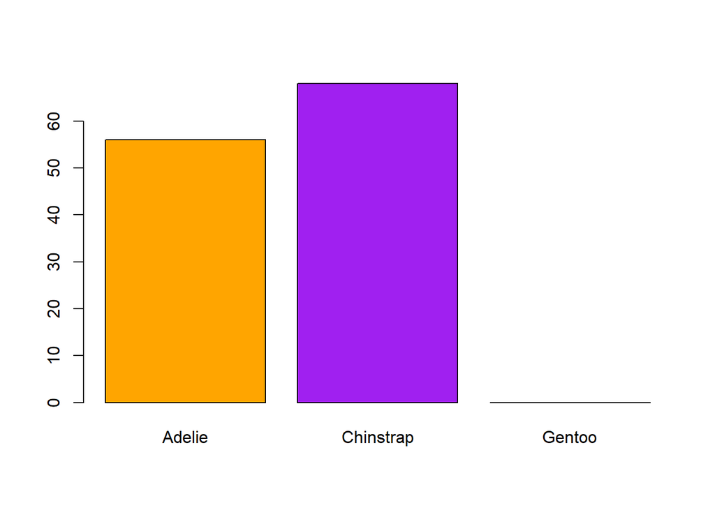

```r
countDream <- table(islaDream$species)
barplot(countDream, col = c("orange", "purple", "blue"))
```

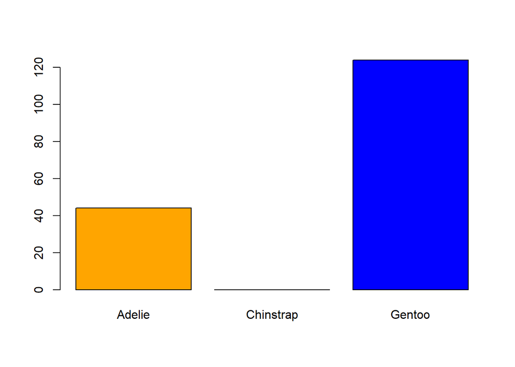

```r
countBiscoe <- table(islaBiscoe$species)
barplot(countBiscoe, col= c("orange", "purple", "blue"))
```

### a) ¿Qué especie se ha muestreado en las tres islas?

La especie muestreada en las tres islas es Adelie

### b) ¿Cuántos individuos se han muestreado en la isla Dream?

```r
dplyr::count(islaDream)
```

```
## # A tibble: 1 x 1
##       n
##   <int>
## 1   124
```

En la isla Dream se han muestreado 124 individuos.

## 3) Gráfico multipanel de cajas y bigotes del tamaño de los pingüinos según su sexo, donde aparezca un panel para cada especie.

```r
levels(penguins$species)
```

```
## [1] "Adelie"    "Chinstrap" "Gentoo"
```

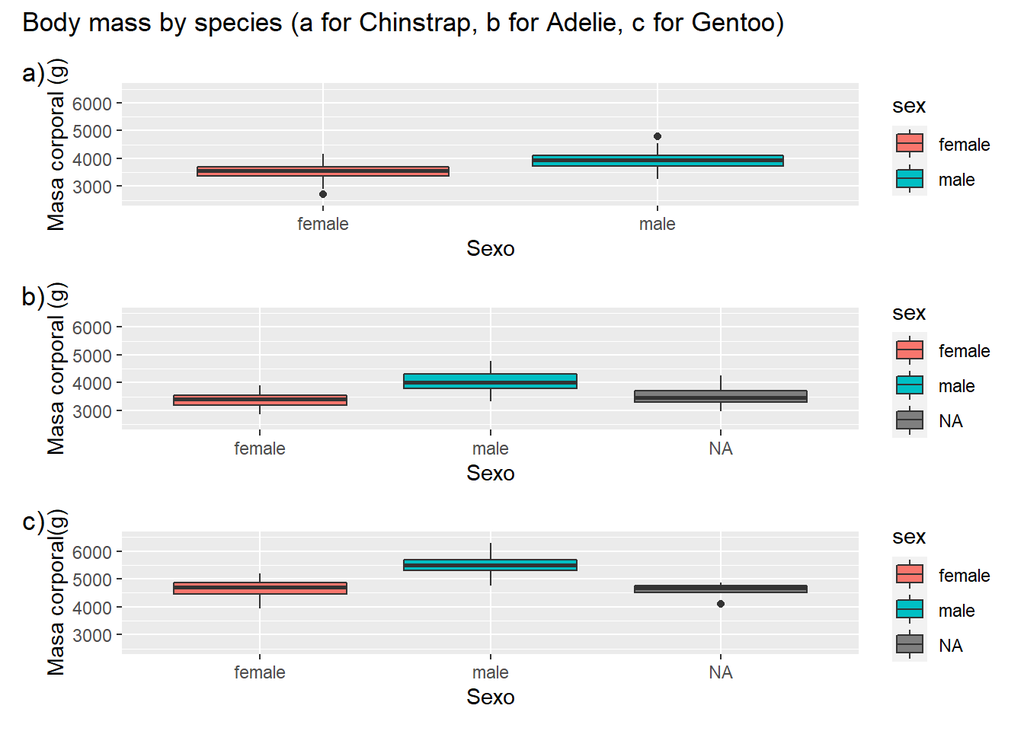

```r
chinstrap <- penguins[penguins$species == "Chinstrap",]

p1 <-ggplot(chinstrap, aes(y= body_mass_g, group= sex, x= sex, fill= sex))+
geom_boxplot()+ ylim(c(2500, 6500))+ ylab("Masa corporal (g)") +xlab("Sexo")

adelie <- penguins[penguins$species == "Adelie",]

p2 <-ggplot(adelie, aes(y= body_mass_g, group= sex, x= sex, fill= sex))+
geom_boxplot()+ ylim(c(2500, 6500))+ ylab("Masa corporal (g)") +xlab("Sexo")

gentoo <- penguins[penguins$species == "Gentoo",]

p3 <-ggplot(gentoo,aes(y= body_mass_g, x= sex, fill= sex), ylim= c(2500, 6500))+
geom_boxplot()+ ylim(c(2500, 6500))+ ylab("Masa corporal(g)")+xlab("Sexo")

p1 / p2 / p3 + plot_annotation(title = "Body mass by species (a for Chinstrap, b for Adelie, c for Gentoo)",tag_levels = "a", tag_suffix=")")
```

### 3.1)¿Qué especie tiene mayor tamaño?

Gentoo

### 3.2) ¿En qué especie las hembras y los machos tienen un tamaño más similar?

En la especie Chinstrap